# Week5_textlytics

Raka

10/26/2020

## Assignment 1: Detecting vandalism on Wikipedia

Wikipedia is a free online encyclopedia that anyone can edit and contribute to. It is available in many languages and is growing all the time. On the English language version of Wikipedia:

```
There are currently 4.7 million pages.
There have been a total over 760 million edits (also called revisions) over its lifetime.
There are approximately 130,000 edits per day.
```

One of the consequences of being editable by anyone is that some people vandalize pages. This can take the form of removing content, adding promotional or inappropriate content, or more subtle shifts that change the meaning of the article. With this many articles and edits per day it is difficult for humans to detect all instances of vandalism and revert (undo) them. As a result, Wikipedia uses bots - computer programs that automatically revert edits that look like vandalism. In this assignment we will attempt to develop a vandalism detector that uses machine learning to distinguish between a valid edit and vandalism.

The data for this problem is based on the revision history of the page Language. Wikipedia provides a history for each page that consists of the state of the page at each revision. Rather than manually considering each revision, a script was run that checked whether edits stayed or were reverted. If a change was eventually reverted then that revision is marked as vandalism. This may result in some misclassifications, but the script performs well enough for our needs.

As a result of this preprocessing, some common processing tasks have already been done, including lower-casing and punctuation removal. The columns in the dataset are:

```
Vandal = 1 if this edit was vandalism, 0 if not.
Minor = 1 if the user marked this edit as a "minor edit", 0 if not.
Loggedin = 1 if the user made this edit while using a Wikipedia account, 0 if they did not.
Added = The unique words added.
Removed = The unique words removed.
```

Notice the repeated use of unique. The data we have available is not the traditional bag of words - rather it is the set of words that were removed or added. For example, if a word was removed multiple times in a revision it will only appear one time in the “Removed” column.

```r
wiki <- read.csv("wiki.csv", stringsAsFactors = FALSE)
str(wiki)
```

```
## 'data.frame':    3876 obs. of  7 variables:
##  $ X.1     : int  1 2 3 4 5 6 7 8 9 10 ...
##  $ X       : int  1 2 3 4 5 6 7 8 9 10 ...
##  $ Vandal  : int  0 0 0 0 0 0 0 0 0 0 ...
##  $ Minor   : int  1 1 0 1 1 0 0 0 1 0 ...
##  $ Loggedin: int  1 1 1 0 1 1 1 1 1 0 ...
##  $ Added   : chr  "  represent psycholinguisticspsycholinguistics orthographyorthography help text all actions through human ethno"| __truncated__ " website external links" " " " afghanistan used iran mostly that farsiis is countries some xmlspacepreservepersian parts tajikestan region" ...
##  $ Removed : chr  " " " talklanguagetalk" " regarded as technologytechnologies human first" "  represent psycholinguisticspsycholinguistics orthographyorthography help all actions through ethnologue relat"| __truncated__ ...
```

```r
table(wiki$Vandal)
```

```
##
##    0    1
## 2061 1815
```

# Bags of words

We will now use the bag of words approach to build a model. We have two columns of textual data, with different meanings. For example, adding rude words has a different meaning to removing rude words. We’ll start like we did in class by building a document term matrix from the Added column. The text already is lowercase and stripped of punctuation. So to pre-process the data, just complete the following four steps:

1. Create the corpus for the Added column, and call it “corpusAdded”.
2. Remove the English-language stopwords.
3. Stem the words.
4. Build the DocumentTermMatrix, and call it dtmAdded.

If the code length(stopwords(“english”)) does not return 174 for you, then please run the line of code in this file, which will store the standard stop words in a variable called sw. When removing stop words, use tm_map(corpusAdded, removeWords, sw) instead of tm_map(corpusAdded, removeWords, stopwords(“english”)).

How many terms appear in dtmAdded?

```r
library(tm)
corpusAdded <- Corpus(VectorSource(wiki$Added))
strwrap(corpusAdded[[1]])
```

```
##  [1] "represent psycholinguisticspsycholinguistics orthographyorthography"
##  [2] "help text all actions through human ethnologue relationships"
##  [3] "linguistics regarded writing languages to other listing"
##  [4] "xmlspacepreservelanguages metaverse formal term philology common each"
##  [5] "including phonologyphonology often ten list humans affiliation see"
##  [6] "computer are speechpathologyspeech our what for ways dialects please"
##  [7] "artificial written body be of quite hypothesis found alone refers by"
##  [8] "about language profanity study programming priorities rosenfelders"
##  [9] "technologytechnologies makes or first among useful languagephilosophy"
## [10] "one sounds use area create phrases mark their genetic basic families"
## [11] "complete but sapirwhorfhypothesissapirwhorf with talklanguagetalk"
## [12] "population animals this science up vocal can concepts called at and"
## [13] "topics locations as numbers have in pathology different develop 4000"
## [14] "things ideas grouped complex animal mathematics fairly literature"
## [15] "httpwwwzompistcom philosophy most important meaningful a"
## [16] "historicallinguisticsorphilologyhistorical semanticssemantics patterns"
## [17] "the oral"
```

```r
corpusAdded <- tm_map(corpusAdded, removeWords, stopwords("english"))
corpusAdded <- tm_map(corpusAdded, stemDocument)
frequencies <- DocumentTermMatrix(corpusAdded)
frequencies
```

```
## <<DocumentTermMatrix (documents: 3876, terms: 6675)>>
## Non-/sparse entries: 15368/25856932
## Sparsity           : 100%
## Maximal term length: 784
## Weighting          : term frequency (tf)
```

```r
sparse <- removeSparseTerms(frequencies, 0.997)
sparse
```

```
## <<DocumentTermMatrix (documents: 3876, terms: 166)>>
## Non-/sparse entries: 2681/640735
## Sparsity           : 100%
## Maximal term length: 28
## Weighting          : term frequency (tf)
```

# Bags of Words 2

Convert sparseAdded to a data frame called wordsAdded, and then prepend all the words with the letter A, by using the command:

colnames(wordsAdded) = paste(“A”, colnames(wordsAdded))

Now repeat all of the steps we’ve done so far (create a corpus, remove stop words, stem the document, create a sparse document term matrix, and convert it to a data frame) to create a Removed bag-of-words dataframe, called wordsRemoved, except this time, prepend all of the words with the letter R:

colnames(wordsRemoved) = paste(“R”, colnames(wordsRemoved))

How many words are in the wordsRemoved data frame?

```r
wordsAdded <- as.data.frame(as.matrix(sparse))
colnames(wordsAdded) <- paste("A", colnames(wordsAdded))

removedWords <-Corpus(VectorSource(wiki$Removed))
strwrap(removedWords[[1]])
```

```
## [1] ""
```

```r
removedWords <- tm_map(removedWords, removeWords, stopwords("english"))
removedWords <- tm_map(removedWords, stemDocument)
frequencies_rm <- DocumentTermMatrix(removedWords)
frequencies_rm
```

```
## <<DocumentTermMatrix (documents: 3876, terms: 5403)>>
## Non-/sparse entries: 13293/20928735
## Sparsity           : 100%
## Maximal term length: 784
## Weighting          : term frequency (tf)
```

```r
sparse2 <- removeSparseTerms(frequencies_rm, 0.997)
sparse2
```

```
## <<DocumentTermMatrix (documents: 3876, terms: 162)>>
## Non-/sparse entries: 2552/625360
## Sparsity           : 100%
## Maximal term length: 28
## Weighting          : term frequency (tf)
```

```r
wordsRemoved <- as.data.frame(as.matrix(sparse2))
colnames(wordsRemoved) <-  paste("R", colnames(wordsRemoved))
```

# Bags of Words 3

Combine the two data frames into a data frame called wikiWords with the following line of code:

wikiWords = cbind(wordsAdded, wordsRemoved)

The cbind function combines two sets of variables for the same observations into one data frame. Then add the Vandal column (HINT: remember how we added the dependent variable back into our data frame in the Twitter lecture). Set the random seed to 123 and then split the data set using sample.split from the “caTools” package to put 70% in the training set.

What is the accuracy on the test set of a baseline method that always predicts “not vandalism” (the most frequent outcome)?

```r
library(caTools)
wikiWords <- cbind(wordsAdded, wordsRemoved)
wikiWords$Vandal <- wiki$Vandal

set.seed(123)
```

```r
split <- sample.split(wikiWords$Vandal, SplitRatio = 0.7)

train <- subset(wikiWords, split == TRUE)
test <- subset(wikiWords, split == FALSE)

table(test$Vandal)
```

```
##
##   0   1
## 618 545
```

```r
(618)/(618+545)
```

```
## [1] 0.5313844
```

# Bags of words 4

Build a CART model to predict Vandal, using all of the other variables as independent variables. Use the training set to build the model and the default parameters (don’t set values for minbucket or cp).

What is the accuracy of the model on the test set, using a threshold of 0.5? (Remember that if you add the argument type=“class” when making predictions, the output of predict will automatically use a threshold of 0.5.)

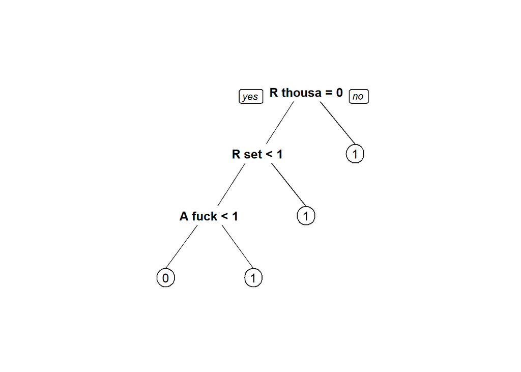

```r
library(rpart)
library(rpart.plot)
wikiCART <- rpart(Vandal ~ ., data = train, method = 'class')
prp(wikiCART)
```

```r
predCART <- predict(wikiCART, newdata = test, type = 'class')
table(test$Vandal, predCART)
```

```
##    predCART
##       0   1
##   0 614   4
##   1 526  19
```

```r
(614+19)/(614+19+4+526)
```

```
## [1] 0.544282
```

# Part 2.1 Problem-specific knowledge

The key class of words we will use are website addresses. “Website addresses” (also known as URLs - Uniform Resource Locators) are comprised of two main parts. An example would be “http://www.google.com”. The first part is the protocol, which is usually “http” (HyperText Transfer Protocol). The second part is the address of the site, e.g. “www.google.com”. We have stripped all punctuation so links to websites appear in the data as one word, e.g. “httpwwwgooglecom”. We hypothesize that given that a lot of vandalism seems to be adding links to promotional or irrelevant websites, the presence of a web address is a sign of vandalism.

```r
wikiWords2 <- wikiWords
wikiWords2$http <- ifelse(grepl("http", wiki$Added, fixed = TRUE), 1, 0)
table(wikiWords2$http)
```

```
##
##    0    1
## 3659  217
```

# Prob-specific knowledge 2

In problem 1.5, you computed a vector called “spl” that identified the observations to put in the training and testing sets. Use that variable (do not recompute it with sample.split) to make new training and testing sets:

wikiTrain2 = subset(wikiWords2, spl==TRUE)

wikiTest2 = subset(wikiWords2, spl==FALSE)

Then create a new CART model using this new variable as one of the independent variables.

What is the new accuracy of the CART model on the test set, using a threshold of 0.5?

```r
split <- sample.split(wikiWords2$Vandal, SplitRatio = 0.7)
wikiTrain2 <- subset(wikiWords2, split == TRUE)
wikiTest2 <- subset(wikiWords2, split == FALSE)

wikiCART2 <- rpart(Vandal ~ ., data = wikiTrain2, method = 'class')
predCART2 <- predict(wikiCART2, newdata = wikiTest2, type = "class")
table(wikiTest2$Vandal, predCART2)
```

```
##    predCART2
##       0   1
##   0 606  12
##   1 481  64
```

```r
(605+70)/(605+70+13+475)
```

```
## [1] 0.5803955
```

# Problem-specific knowledge 3

Another possibility is that the number of words added and removed is predictive, perhaps more so than the actual words themselves. We already have a word count available in the form of the document-term matrices (DTMs).

Sum the rows of dtmAdded and dtmRemoved and add them as new variables in your data frame wikiWords2 (called NumWordsAdded and NumWordsRemoved) by using the following commands:

wikiWords2$NumWordsAdded = rowSums(as.matrix(dtmAdded))

wikiWords2$NumWordsRemoved = rowSums(as.matrix(dtmRemoved))

What is the average number of words added?

```r
wikiWords2$NumWordsAdded <- rowSums(as.matrix(frequencies))

wikiWords2$NumWordsRemoved <- rowSums(as.matrix(frequencies_rm))

mean(wikiWords2$NumWordsAdded)
```

```
## [1] 4.050052
```

# Problem-specific knowledge 5

In problem 1.5, you computed a vector called “spl” that identified the observations to put in the training and testing sets. Use that variable (do not recompute it with sample.split) to make new training and testing sets with wikiWords2. Create the CART model again (using the training set and the default parameters).

What is the new accuracy of the CART model on the test set?

```r
train_new <- subset(wikiWords2, split == TRUE)
test_new <- subset(wikiWords2, split == FALSE)

CART3 <- rpart(Vandal ~ ., data = train_new, method = "class")
predCART3 <- predict(CART3, newdata = test_new, type = "class")

table(test_new$Vandal, predCART3)
```

```
##    predCART3
##       0   1
##   0 495 123
##   1 269 276
```

```r
(514+248)/(514+248+104+297)
```

```
## [1] 0.6552021
```

# Using non-textual data

We have two pieces of “metadata” (data about data) that we haven’t yet used. Make a copy of wikiWords2, and call it wikiWords3:

wikiWords3 = wikiWords2

Then add the two original variables Minor and Loggedin to this new data frame:

wikiWords3$Minor = wiki$Minor

wikiWords3$Loggedin = wiki$Loggedin

In problem 1.5, you computed a vector called “spl” that identified the observations to put in the training and testing sets. Use that variable (do not recompute it with sample.split) to make new training and testing sets with wikiWords3.

Build a CART model using all the training data. What is the accuracy of the model on the test set?

```r
wikiWords3 <- wikiWords2

wikiWords3$Minor <- wiki$Minor
wikiWords3$Loggedin <- wiki$Loggedin

train_new2 <- subset(wikiWords3, split == TRUE)
test_new2 <- subset(wikiWords3, split == FALSE)

CART4 <- rpart(Vandal ~ ., data = train_new2, method = "class")
predCART4 <- predict(CART4, newdata = test_new2, type = "class")

table(test_new2$Vandal, predCART4)
```

```
##    predCART4
##       0   1
##   0 566  52
##   1 263 282
```

```r
(595+241)/(595+241+23+304)
```

```
## [1] 0.7188306
```

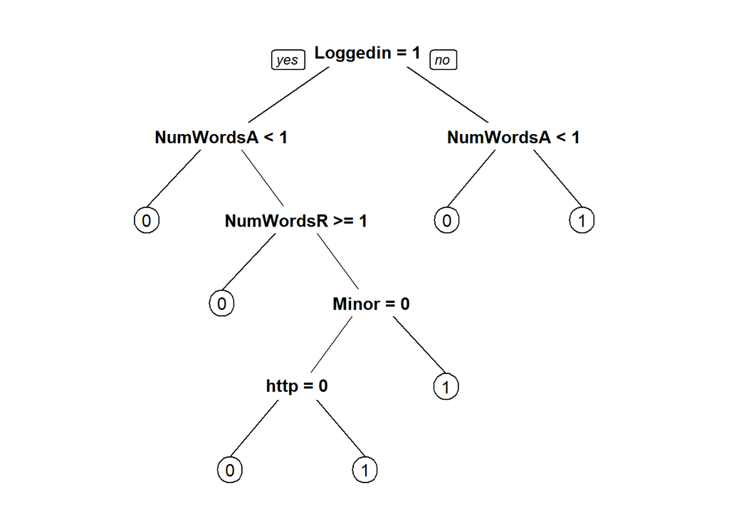

```r
prp(CART4)
```

## Assignment 2: Automating Reviews in Medicine

The medical literature is enormous. Pubmed, a database of medical publications maintained by the U.S. National Library of Medicine, has indexed over 23 million medical publications. Further, the rate of medical publication has increased over time, and now there are nearly 1 million new publications in the field each year, or more than one per minute.

The large size and fast-changing nature of the medical literature has increased the need for reviews, which search databases like Pubmed for papers on a particular topic and then report results from the papers found. While such reviews are often performed manually, with multiple people reviewing each search result, this is tedious and time consuming. In this problem, we will see how text analytics can be used to automate the process of information retrieval.

```r
trials <- read.csv("clinical_trial.csv", stringsAsFactors = FALSE)
str(trials)
```

```
## 'data.frame':    1860 obs. of  3 variables:
##  $ title   : chr  "Treatment of Hodgkin's disease and other cancers with 1,3-bis(2-chloroethyl)-1-nitrosourea (BCNU; NSC-409962)." "Cell mediated immune status in malignancy--pretherapy and post-therapy assessment." "Neoadjuvant vinorelbine-capecitabine versus docetaxel-doxorubicin-cyclophosphami…
##  $ abstract: chr  "" "Twenty-eight cases of malignancies of different kinds were studied to assess T-cell activity and population bef"| __truncated__ "BACKGROUND: Among breast cancer patients, nonresponse to initial neoadjuvant chemotherapy is associated with un"| __truncated__ "BACKGROUND: Taxan…
##  $ trial   : int  1 0 1 1 1 0 1 0 0 0 ...
```

```r
max(nchar(trials$abstract))
```

```
## [1] 3708
```

```r
table(nchar(trials$abstract))
```

```
##
##    0  243  273  282  288  290  332  337  345  363  378  420  434  444  447  454
##  112    1    1    1    1    1    1    1    1    1    1    1    1    1    1    1
##  463  464  465  468  469  477  482  483  489  491  492  501  507  511  514  519
##    1    1    1    1    1    2    1    1    1    1    1    1    1    1    1    1
##  528  541  543  548  559  563  566  567  576  584  585  588  591  593  600  601
##    1    1    1    2    1    1    2    1    1    1    1    1    1    1    1    1
##  604  610  615  617  620  627  628  631  634  639  644  645  647  655  656  660
##    1    1    1    2    1    1    2    1    1    1    2    1    1    1    2    2
##  666  671  673  675  681  685  688  695  700  701  713  717  720  721  722  723
##    1    1    1    1    1    1    1    3    1    1    1    2    1    1    1    1
##  725  730  733  735  739  740  741  765  773  775  777  781  782  783  788  795
##    1    1    1    1    1    1    1    2    1    2    1    3    1    1    1    1
##  798  802  805  806  808  811  820  823  825  829  832  834  836  837  838  840
##    1    1    1    1    1    1    1    1    1    1    1    1    2    2    1    1
```

[output cut: 122 more lines]

```r
which.min(nchar(trials$title))
```

```
## [1] 1258
```

```r
trials$title[which.min(nchar(trials$title))]
```

```
## [1] "A decade of letrozole: FACE."
```

# Preparing two Corpora

Because we have both title and abstract information for trials, we need to build two corpora instead of one. Name them corpusTitle and corpusAbstract.

Following the commands from lecture, perform the following tasks (you might need to load the “tm” package first if it isn’t already loaded). Make sure to perform them in this order.

```r
corpusTitle <- Corpus(VectorSource(trials$title))
corpusAbstract <- Corpus(VectorSource(trials$abstract))

corpusTitle <- tm_map(corpusTitle, tolower)
corpusAbstract <- tm_map(corpusAbstract, tolower)
corpusTitle <- tm_map(corpusTitle, removePunctuation)
corpusAbstract <- tm_map(corpusAbstract, removePunctuation)
corpusTitle <- tm_map(corpusTitle, removeWords, stopwords("english"))
corpusAbstract <- tm_map(corpusAbstract, removeWords, stopwords("english"))
corpusTitle <- tm_map(corpusTitle, stemDocument)
corpusAbstract <- tm_map(corpusAbstract, stemDocument)
dtmTitle <- DocumentTermMatrix(corpusTitle)
dtmTitle
```

```
## <<DocumentTermMatrix (documents: 1860, terms: 2837)>>
## Non-/sparse entries: 23417/5253403
## Sparsity           : 100%
## Maximal term length: 49
## Weighting          : term frequency (tf)
```

```r
dtmAbstract <- DocumentTermMatrix(corpusAbstract)
dtmAbstract
```

```
## <<DocumentTermMatrix (documents: 1860, terms: 12457)>>
## Non-/sparse entries: 153302/23016718
## Sparsity           : 99%
## Maximal term length: 67
## Weighting          : term frequency (tf)
```

```r
dtmTitle <- removeSparseTerms(dtmTitle, 0.95)
dtmAbstract <- removeSparseTerms(dtmAbstract, 0.95)


dtmTitle <- as.data.frame(as.matrix(dtmTitle))
dtmAbstract <- as.data.frame(as.matrix(dtmAbstract))

max(colSums(dtmAbstract))
```

```
## [1] 8381
```

# Building the model

We want to combine dtmTitle and dtmAbstract into a single data frame to make predictions. However, some of the variables in these data frames have the same names. To fix this issue, run the following commands:

colnames(dtmTitle) = paste0(“T”, colnames(dtmTitle))

colnames(dtmAbstract) = paste0(“A”, colnames(dtmAbstract))

What was the effect of these functions?

```r
colnames(dtmTitle) <- paste0("T", colnames(dtmTitle))

colnames(dtmAbstract) <- paste0("A", colnames(dtmAbstract))

dtm <- cbind(dtmTitle, dtmAbstract)
dtm$trial <- trials$trial
ncol(dtm)
```

```
## [1] 367
```

# Building the model 2

Now that we have prepared our data frame, it’s time to split it into a training and testing set and to build regression models. Set the random seed to 144 and use the sample.split function from the caTools package to split dtm into data frames named “train” and “test”, putting 70% of the data in the training set.

What is the accuracy of the baseline model on the training set? (Remember that the baseline model predicts the most frequent outcome in the training set for all observations.)

```r
set.seed(144)
spl <- sample.split(dtm$trial, SplitRatio = 0.7)

train <- subset(dtm, spl == TRUE)
test <- subset(dtm, spl == FALSE)

table(test$trial)
```

```
##
##   0   1
## 313 245
```

```r
(313)/(313+245)
```

```
## [1] 0.5609319
```

# Building the CART model

Build a CART model called trialCART, using all the independent variables in the training set to train the model, and then plot the CART model. Just use the default parameters to build the model (don’t add a minbucket or cp value). Remember to add the method=“class” argument, since this is a classification problem.

What is the name of the first variable the model split on?

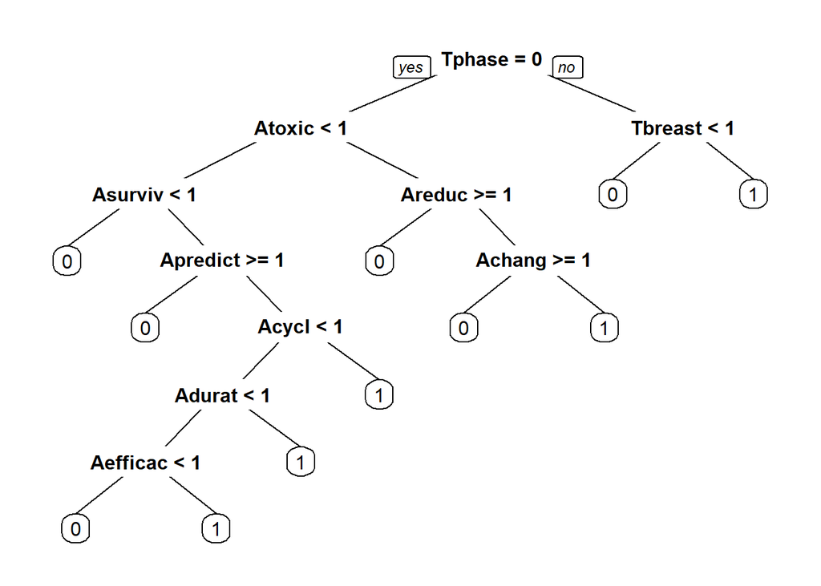

```r
trialCART <- rpart(trial ~ ., data = train, method = "class")
prp(trialCART)
```

```r
pred <- predict(trialCART, newdata = test)
pred.prob <- pred[,2]
max(pred.prob)
```

```
## [1] 0.8718861
```

```r
length(pred)
```

```
## [1] 1116
```

```r
pred2 <- predict(trialCART, newdata = train, type = "class")
table(train$trial, pred2)
```

```
##    pred2
##       0   1
##   0 631  99
##   1 131 441
```

```r
(631+441)/(631+441+99+131) # accuracy
```

```
## [1] 0.8233487
```

```r
(441)/(441+131) # sensitivity
```

```
## [1] 0.770979
```

```r
631/(631+99) # specificity
```

```
## [1] 0.8643836
```

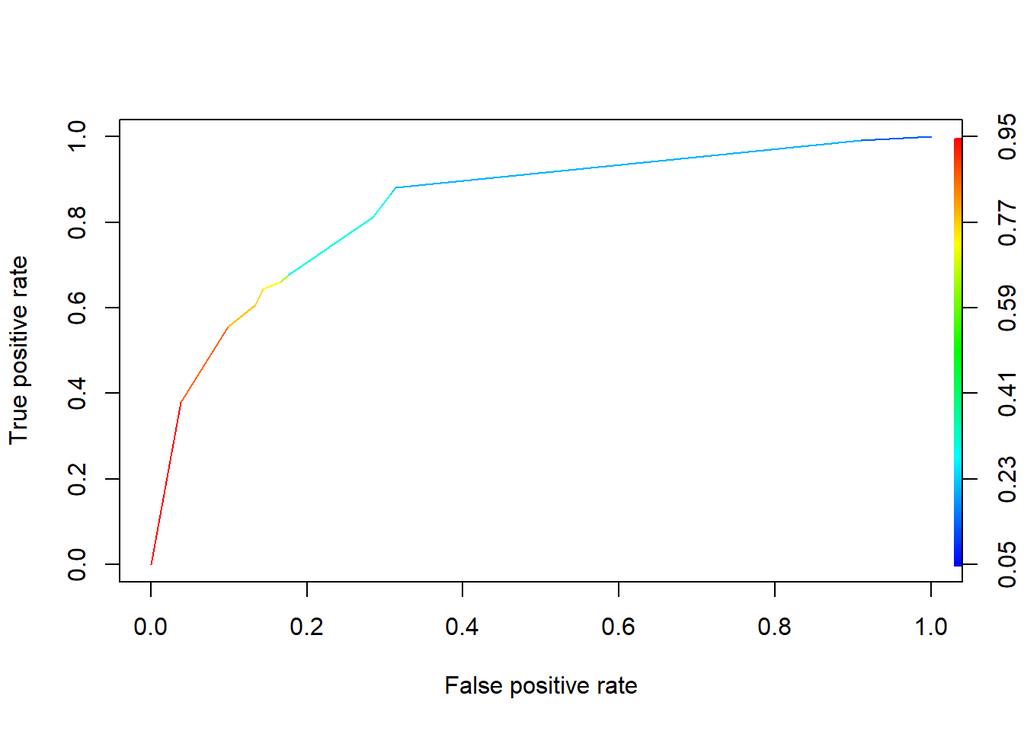

```r
library(ROCR)
predROCR <- prediction(pred.prob, test$trial)
perfROCR <- performance(predROCR, "tpr", "fpr")
plot(perfROCR, colorize = TRUE)
```

```r
performance(predROCR, "auc")@y.values
```

```
## [[1]]
## [1] 0.8371063
```

# Assignment 3: Separating Span from Ham

Nearly every email user has at some point encountered a “spam” email, which is an unsolicited message often advertising a product, containing links to malware, or attempting to scam the recipient. Roughly 80-90% of more than 100 billion emails sent each day are spam emails, most being sent from botnets of malware-infected computers. The remainder of emails are called “ham” emails.

As a result of the huge number of spam emails being sent across the Internet each day, most email providers offer a spam filter that automatically flags likely spam messages and separates them from the ham. Though these filters use a number of techniques (e.g. looking up the sender in a so-called “Blackhole List” that contains IP addresses of likely spammers), most rely heavily on the analysis of the contents of an email via text analytics.

Begin by loading the dataset emails.csv into a data frame called emails. Remember to pass the stringsAsFactors=FALSE option when loading the data.

How many emails are in the dataset?

```r
emails <- read.csv("emails.csv")
table(emails$spam)
```

```
##
##    0    1
## 4360 1368
```

```r
max(nchar(emails$text))
```

```
## [1] 43952
```

```r
which.min(nchar(emails$text))
```

```
## [1] 1992
```

# Preparing the Corpus

Follow the standard steps to build and pre-process the corpus:

1. Build a new corpus variable called corpus.
2. Using tm_map, convert the text to lowercase.
3. Using tm_map, remove all punctuation from the corpus.
4. Using tm_map, remove all English stopwords from the corpus.
5. Using tm_map, stem the words in the corpus.
6. Build a document term matrix from the corpus, called dtm.

```r
corpus_mail <- Corpus(VectorSource(emails$text))

corpus_mail <- tm_map(corpus_mail, tolower)
corpus_mail <- tm_map(corpus_mail, removePunctuation)
corpus_mail <- tm_map(corpus_mail, removePunctuation)
corpus_mail <- tm_map(corpus_mail, removeWords, stopwords("english"))
corpus_mail <- tm_map(corpus_mail, stemDocument)
dtm <- DocumentTermMatrix(corpus_mail)
dtm
```

```
## <<DocumentTermMatrix (documents: 5728, terms: 28687)>>
## Non-/sparse entries: 481719/163837417
## Sparsity           : 100%
## Maximal term length: 24
## Weighting          : term frequency (tf)
```

```r
#limited dm

spdtm <- removeSparseTerms(dtm, 0.95)
spdtm
```

```
## <<DocumentTermMatrix (documents: 5728, terms: 330)>>
## Non-/sparse entries: 213551/1676689
## Sparsity           : 89%
## Maximal term length: 10
## Weighting          : term frequency (tf)
```

```r
emailsSparse <- as.data.frame(as.matrix(spdtm))
colnames(emailsSparse) <- make.names(colnames(emailsSparse)) #approproiating names
colSums(emailsSparse)
```

```
##       busi      chang    compani     corpor        day       done     effect
##       2313       1035       2290        565       1860        337        471
##     effort       even       full       good     inform   interest       list
##        473        622        469       1097       2701       1814       1410
##       look       made       make      manag     market       much      order
##       2003        622       1884       2600       2750        861       1210
##     origin    product     provid     realli     result        see    special
##        892       1197       1405        417        655       1567        451
##    subject     system        use     websit       will     within    without
##      10202       1118       2330        700       8252        732        389
##    continu      group       like      trade        tri     approv        ask
##        552       2604       2352       1366        661        648        871
##    complet     credit       form       hear       home        new      offer
##        707        960        664        469        660       2281       1171
##   opportun       rate       take       time      visit       want        way
##        918        717       1361       3145       1126       1488        864
##      addit      click        com        fax       mail     messag        now
##        774        769       5443       1038       2269       1983       1300
##      phone    request    version       best        end        get      great
##       1001       1344        564       1291        635       2462        837
##      money    softwar     custom      hello        one      onlin      pleas
##        776        739        796        534       2108        518       5113
##     access    account      allow    alreadi       also     applic       area
##        789        829        450        446       1864        567        489
##     assist       base     believ        buy        can       cost      creat
##        598        837        456        442       4257        821        413
##    current     design    develop     differ   director    discuss        due
##       1044        457       1882        598        705       1326        445
##      email      event     expect       file    forward      futur        gas
##       2066        552        554        770       3161        722       1070
##       give      given       high     import     includ    increas   industri
##       1055        453        624        530       1238        491        970
##     invest     involv       just       know      locat       mani        may
##        867        405       1354       2614        485        758       2465
##       mean    mention      might      month       need       note     number
##        390        355        577        958       2328        688       1182
##      offic       oper     person      posit    possibl    present      price
##       1068        820        767       1104        796       1543       2694
##    problem    process    project       read      relat     report     requir
##        666        975       1522        413        694       1279        736
```

[output cut: 41 more lines]

```
##        367       1059        541        431        626        657        438
##     energi     london      updat    suggest     option     monday      kevin
##       2179        843        606        554       1488        649        656
##       book       deal      invit    tuesday  interview    schedul     school
##        756        498        647        474       1333       1071        655
##      model     financ       morn     attend     robert    student      april
##       2199       1073        586        573        482        726        682
##       talk     arrang      deriv   thursday      resum        doc     confer
##        981        410        676        575        933        675       1297
##  wednesday        edu     friday        ect        hou       vinc       X853
##        464       1627        854      11427       5577       8532        462
##    shirley      enron   kaminski       X713   crenshaw     vkamin     gibner
##       1689      13388       4801       1097       1115        301        633
##    stinson
##       1051
```

```r
colSums(emailsSparse)[324]
```

```
## enron
## 13388
```

```r
which.max(colSums(emailsSparse))
```

```
## enron
##   324
```

```r
emailsSparse$spam <- emails$spam

#only ham
ham_mails <- subset(emailsSparse, spam == 0)
length(colSums(ham_mails))
```

```
## [1] 331
```

```r
sort(colSums(subset(emailsSparse, spam == 0)))
```

```
##       spam       life      remov      money      onlin    without     websit
##          0         80        103        114        173        191        194
##      click    special       wish      repli        buy        net       link
##        217        226        229        239        243        243        247
##     immedi       done       mean     design        lot     effect       info
##        249        254        259        261        268        270        273
##       read     either      write       line      begin    success      sorri
##        279        279        286        289        291        293        293
##     involv    softwar      creat     better     vkamin        say       keep
##        294        299        299        301        301        305        306
##      bring     believ       full    increas     realli    mention    thought
##        311        313        317        320        324        325        325
##     invest       idea      secur     specif      sever     experi      thing
##        327        327        337        338        340        346        347
##      allow        due      check       type      happi     return     expect
##        348        351        351        352        354        355        356
##      short     effort       open   internet     sincer     public     recent
##        357        358        360        361        361        364        368
##      anoth    alreadi       home       made    respond      given        etc
##        369        372        375        380        382        383        385
##        put     within      place    version      right      hello       sure
##        385        386        388        390        390        395        396
##       area        run     arrang    account       join       hour      locat
##        397        398        399        401        403        404        406
##     togeth     import      engin        per     corpor       high     result
##        406        411        411        412        414        416        418
##       hear      final       deal     applic       even        web     custom
##        420        422        423        428        429        430        433
##       soon       long       sinc      futur     member      event       X000
##        435        436        439        440        446        447        447
##        don       part       feel    tuesday  wednesday       unit      still
##        450        450        453        454        456        457        457
##       site       X853    continu understand    resourc     robert       form
##        458        461        464        464        466        466        468
##    analysi      point     assist    confirm     differ     intern      might
##        468        474        475        485        489        489        490
##       real       case      howev    comment    complet        abl       rate
##        490        492        496        505        515        515        516
##    appreci        tri       move      updat     approv    suggest       free
##        518        521        526        527        533        533        535
```

[output cut: 41 more lines]

```
##       1429       1432       1440       1497       1516       1523       1527
##     messag    houston       also       look        edu       corp    shirley
##       1538       1577       1604       1607       1620       1643       1687
##    develop        get        new        use        let     regard     inform
##       1691       1768       1777       1784       1856       1859       1883
##       need      power        may       like       risk     energi     market
##       1890       1972       1976       1980       2097       2124       2150
##      model      price       work      manag       know      group       meet
##       2170       2191       2293       2334       2345       2474       2544
##       time   research    forward      X2001        can      thank        com
##       2552       2752       2952       3060       3426       3558       4444
##      pleas   kaminski      X2000        hou       will       vinc    subject
##       4494       4801       4935       5569       6802       8531       8625
##        ect      enron
##      11417      13388
```

```r
length(sort(colSums(subset(emailsSparse, spam == 0))))
```

```
## [1] 331
```

```r
length(sort(colSums(ham_mails)))
```

```
## [1] 331
```

```r
length(which(colSums(ham_mails)>10000))
```

```
## [1] 2
```

```r
length(which(colSums(ham_mails)>1000))
```

```
## [1] 83
```

```r
length(which(colSums(ham_mails)>5000))
```

```
## [1] 6
```

```r
length(which(colSums(emailsSparse)>1000))
```

```
## [1] 119
```

```r
subset(emailsSparse, spam == 1)
```

```
##     busi chang compani corpor day done effect effort even full good inform
## 1      2     2       3      1   1    1      2      1    1    1    2      1
## 2      0     0       0      0   0    0      0      0    0    0    0      0
## 3      0     0       0      0   0    0      0      0    0    0    0      0
## 4      0     0       0      0   0    0      0      0    0    0    0      2
## 5      0     0       0      0   0    0      0      0    0    0    0      0
## 6      0     0       0      0   1    0      0      0    0    0    0      0
## 7      3     1      16      0   0    0      0      1    1    0    0     11
## 8      0     0       0      0   0    0      1      0    1    0    0      0
## 9      2     0       0      0   0    0      0      0    0    0    0      0
## 10     0     0       0      0   0    0      1      0    1    0    0      0
## 11     0     0       0      0   0    0      0      0    0    0    0      0
## 12     0     0       0      0   0    0      1      0    1    0    0      0
## 13     0     0       0      0   1    0      0      0    0    0    0      0
## 14     7     0      17      0   0    0      0      1    0    0    1      8
```

[output cut: 8470 more lines]

```r
sort(colSums(subset(emailsSparse, spam == 1)))
```

```
##      enron   kaminski       X713   crenshaw     vkamin     gibner    stinson
##          0          0          0          0          0          0          0
##       vinc       X853      kevin        doc    shirley      deriv    houston
##          1          1          2          2          2          3          5
##      april      resum        edu     friday  wednesday        hou        ect
##          5          5          7          7          8          8         10
##     arrang  interview     london     attend     robert    student    schedul
##         11         13         15         15         16         16         17
##   thursday     monday       john    tuesday     attach    suggest    appreci
##         17         19         20         20         21         21         23
##       mark    comment      begin    analysi      X2001      model    mention
##         25         26         26         27         29         29         30
##       hope      X2000     togeth      invit     confer    univers     financ
##         30         32         32         33         33         34         35
##       talk     either        run      shall       morn      happi    thought
##         38         39         39         40         40         42         42
##     depart    confirm    respond     school       hear       corp        etc
##         46         47         48         48         49         49         49
##      howev      sorri       idea     energi    discuss       open     option
##         49         50         51         55         56         56         56
## understand       soon     experi      cours     associ      point      bring
##         57         57         59         59         62         62         63
##   director   particip       join      anoth      still   research      final
##         65         65         66         66         66         68         68
##        set     specif       case      given       juli    problem        put
##         69         69         69         70         71         73         73
##        ask    alreadi        fax        abl       deal       team       book
##         74         74         75         75         75         76         76
##      locat       issu       meet      updat        lot     sincer      short
##         79         79         79         79         80         80         82
##     better       sinc       done     recent   question    possibl        end
##         82         82         83         83         83         84         85
##   contract       move      might       data    continu       note    resourc
##         85         86         87         87         88         88         90
##      sever       feel       area   communic     realli        due     origin
##         90         90         92         92         93         94         96
##     direct       unit       copi       long     member       sure      allow
##         96         97         97         98         99         99        102
##       dear      write     public      event        let     differ       file
##        104        104        104        105        107        109        111
```

[output cut: 41 more lines]

```
##        385        393        395        396        415        420        420
##    product        www    account     provid       need    softwar     messag
##        421        426        428        435        438        440        445
##       site    address        may       list      price        new     websit
##        455        461        489        503        503        504        506
##     report      secur       just      offer     invest      order        use
##        507        520        524        528        540        541        546
##      click       X000        now        one       time     market       http
##        552        560        575        592        593        600        600
##       make       free      pleas      money        get     receiv     inform
##        603        606        619        662        694        727        818
##        can      email       busi       mail        com    compani       spam
##        831        865        897        917        999       1065       1368
##       will    subject
##       1450       1577
```

# Machine learning models

First, convert the dependent variable to a factor with “emailsSparse$spam = as.factor(emailsSparse$spam)”.

Next, set the random seed to 123 and use the sample.split function to split emailsSparse 70/30 into a training set called “train” and a testing set called “test”. Make sure to perform this step on emailsSparse instead of emails.

Using the training set, train the following three machine learning models. The models should predict the dependent variable “spam”, using all other available variables as independent variables. Please be patient, as these models may take a few minutes to train.

1. A logistic regression model called spamLog. You may see a warning message here - we’ll discuss this more later.
2. A CART model called spamCART, using the default parameters to train the model (don’t worry about adding minbucket or cp). Remember to add the argument method=“class” since this is a binary classification problem.
3. A random forest model called spamRF, using the default parameters to train the model (don’t worry about specifying ntree or nodesize). Directly before training the random forest model, set the random seed to 123 (even though we’ve already done this earlier in the problem, it’s important to set the seed right before training the model so we all obtain the same results. Keep in mind though that on certain operating systems, your results might still be slightly different).

For each model, obtain the predicted spam probabilities for the training set. Be careful to obtain probabilities instead of predicted classes, because we will be using these values to compute training set AUC values. Recall that you can obtain probabilities for CART models by not passing any type parameter to the predict() function, and you can obtain probabilities from a random forest by adding the argument type=“prob”. For CART and random forest, you need to select the second column of the output of the predict() function, corresponding to the probability of a message being spam.

You may have noticed that training the logistic regression model yielded the messages “algorithm did not converge” and “fitted probabilities numerically 0 or 1 occurred”. Both of these messages often indicate overfitting and the first indicates particularly severe overfitting, often to the point that the training set observations are fit perfectly by the model. Let’s investigate the predicted probabilities from the logistic regression model.

How many of the training set predicted probabilities from spamLog are less than 0.00001?

```r
emailsSparse$spam <- as.factor(emailsSparse$spam)
set.seed(123)

splt <- sample.split(emailsSparse$spam, SplitRatio = 0.7)

train <- subset(emailsSparse, splt == TRUE)
test <- subset(emailsSparse, splt == FALSE)

# 3 machine learning models

spamLog <- glm(spam ~ ., data = train, family = binomial)
spamCART <- rpart(spam ~., data = train, method = 'class')

set.seed(123)
library(randomForest)
spamRF <- randomForest(spam ~., data = train)

predLog <- predict(spamLog, newdata = train, type = "response")
predLog
```

```
##            1            3            6            7            9           10
## 1.000000e+00 1.000000e+00 1.000000e+00 1.000000e+00 1.000000e+00 1.000000e+00
##           12           13           14           15           17           18
## 1.000000e+00 1.000000e+00 1.000000e+00 1.000000e+00 1.000000e+00 1.000000e+00
##           19           23           25           27           28           29
## 1.000000e+00 1.000000e+00 1.000000e+00 1.000000e+00 1.000000e+00 1.000000e+00
##           30           35           36           38           39           40
## 1.000000e+00 1.000000e+00 1.000000e+00 1.000000e+00 1.000000e+00 1.000000e+00
##           41           42           43           44           45           46
## 1.000000e+00 1.000000e+00 1.000000e+00 1.000000e+00 1.000000e+00 1.000000e+00
##           47           48           49           51           52           54
## 1.000000e+00 1.000000e+00 1.000000e+00 1.000000e+00 1.000000e+00 1.000000e+00
##           55           56           57           60           61           62
## 1.000000e+00 1.000000e+00 1.000000e+00 1.000000e+00 1.000000e+00 1.000000e+00
##           63           64           66           70           72           74
## 1.000000e+00 1.000000e+00 1.000000e+00 9.999999e-01 1.000000e+00 1.000000e+00
##           75           76           77           78           79           80
## 1.000000e+00 1.000000e+00 1.000000e+00 1.000000e+00 1.000000e+00 1.000000e+00
##           81           82           83           85           86           90
## 1.000000e+00 1.000000e+00 1.000000e+00 1.000000e+00 1.000000e+00 1.000000e+00
##           91           92           93           94           95           96
## 1.000000e+00 1.000000e+00 1.000000e+00 1.000000e+00 1.000000e+00 1.000000e+00
##           98           99          100          101          102          103
## 1.000000e+00 1.000000e+00 1.000000e+00 1.000000e+00 1.000000e+00 1.000000e+00
##          105          108          109          110          112          113
## 1.000000e+00 1.000000e+00 1.000000e+00 1.000000e+00 1.000000e+00 1.000000e+00
##          116          117          119          120          121          122
## 4.000000e-01 1.000000e+00 1.000000e+00 1.000000e+00 1.000000e+00 1.000000e+00
##          123          124          125          127          128          129
## 1.000000e+00 1.000000e+00 1.000000e+00 1.000000e+00 1.000000e+00 1.000000e+00
##          131          133          135          136          140          141
## 1.000000e+00 1.000000e+00 1.000000e+00 1.000000e+00 1.000000e+00 1.000000e+00
##          142          143          144          146          147          148
## 1.000000e+00 1.000000e+00 1.000000e+00 1.000000e+00 1.000000e+00 1.000000e+00
##          149          152          153          154          155          156
## 4.000000e-01 1.000000e+00 1.000000e+00 1.000000e+00 1.000000e+00 1.000000e+00
##          157          158          159          160          161          162
## 1.000000e+00 1.000000e+00 1.000000e+00 1.000000e+00 1.000000e+00 1.000000e+00
##          163          164          165          166          168          169
## 1.000000e+00 1.000000e+00 1.000000e+00 1.000000e+00 1.000000e+00 1.000000e+00
```

[output cut: 1283 more lines]

```
## 2.220446e-16 1.542770e-13 2.220446e-16 2.220446e-16 2.220446e-16 2.220446e-16
##         5678         5680         5681         5682         5683         5684
## 2.220446e-16 2.220446e-16 2.220446e-16 2.220446e-16 2.220446e-16 2.220446e-16
##         5685         5686         5687         5688         5689         5692
## 2.220446e-16 2.220446e-16 2.220446e-16 2.220446e-16 2.220446e-16 2.220446e-16
##         5693         5695         5696         5697         5698         5699
## 2.220446e-16 2.220446e-16 2.220446e-16 2.220446e-16 2.220446e-16 2.220446e-16
##         5700         5701         5702         5704         5705         5708
## 2.220446e-16 2.220446e-16 1.547123e-10 2.220446e-16 2.220446e-16 2.220446e-16
##         5710         5712         5713         5716         5717         5718
## 2.220446e-16 2.220446e-16 2.220446e-16 2.220446e-16 2.220446e-16 2.220446e-16
##         5720         5721         5722         5723         5724         5725
## 2.220446e-16 2.220446e-16 2.220446e-16 2.220446e-16 2.220446e-16 2.220446e-16
##         5726         5728
## 2.220446e-16 2.220446e-16
```

```r
length(which(predLog<0.00001))
```

```
## [1] 3046
```

```r
length(which(predLog>0.99999))
```

```
## [1] 954
```

```r
length(which(predLog>0.00001 & predLog<0.99999))
```

```
## [1] 10
```

```r
table(train$spam, predLog > 0.5)
```

```
##
##     FALSE TRUE
##   0  3052    0
##   1     4  954
```

```r
(3052+954)/nrow(train)
```

```
## [1] 0.9990025
```

```r
summary(spamLog)
```

```
##
## Call:
## glm(formula = spam ~ ., family = binomial, data = train)
##
## Deviance Residuals:
##    Min      1Q  Median      3Q     Max
## -1.011   0.000   0.000   0.000   1.354
##
## Coefficients:
##               Estimate Std. Error z value Pr(>|z|)
## (Intercept) -3.082e+01  1.055e+04  -0.003    0.998
## busi        -4.803e+00  1.000e+04   0.000    1.000
## chang       -2.717e+01  2.215e+04  -0.001    0.999
## compani      4.781e+00  9.186e+03   0.001    1.000
## corpor      -8.286e-01  2.818e+04   0.000    1.000
## day         -6.100e+00  5.866e+03  -0.001    0.999
## done         6.828e+00  1.882e+04   0.000    1.000
## effect       1.948e+01  2.100e+04   0.001    0.999
## effort       1.606e+01  5.670e+04   0.000    1.000
## even        -1.654e+01  2.289e+04  -0.001    0.999
## full         2.125e+01  2.190e+04   0.001    0.999
## good         5.399e+00  1.619e+04   0.000    1.000
## inform       2.078e+01  8.549e+03   0.002    0.998
## interest     2.698e+01  1.159e+04   0.002    0.998
## list        -8.692e+00  2.149e+03  -0.004    0.997
## look        -7.031e+00  1.563e+04   0.000    1.000
## made         2.820e+00  2.743e+04   0.000    1.000
## make         2.901e+01  1.528e+04   0.002    0.998
## manag        6.014e+00  1.445e+04   0.000    1.000
## market       7.895e+00  8.012e+03   0.001    0.999
## much         3.775e-01  1.392e+04   0.000    1.000
## order        6.533e+00  1.242e+04   0.001    1.000
## origin       3.226e+01  3.818e+04   0.001    0.999
## product      1.016e+01  1.345e+04   0.001    0.999
## provid       2.422e-01  1.859e+04   0.000    1.000
## realli      -2.667e+01  4.640e+04  -0.001    1.000
## result      -5.002e-01  3.140e+04   0.000    1.000
## see         -1.120e+01  1.293e+04  -0.001    0.999
## special      1.777e+01  2.755e+04   0.001    0.999
## subject      3.041e+01  1.055e+04   0.003    0.998
```

[output cut: 294 more lines]

```
## enron       -8.789e+00  5.719e+03  -0.002    0.999
## kaminski    -1.812e+01  6.029e+03  -0.003    0.998
## X713        -2.427e+01  2.914e+04  -0.001    0.999
## crenshaw     9.994e+01  6.769e+04   0.001    0.999
## vkamin      -6.649e+01  5.703e+04  -0.001    0.999
## gibner       2.901e+01  2.460e+04   0.001    0.999
## stinson     -4.345e+01  2.697e+04  -0.002    0.999
##
## (Dispersion parameter for binomial family taken to be 1)
##
##     Null deviance: 4409.49  on 4009  degrees of freedom
## Residual deviance:   13.46  on 3679  degrees of freedom
## AIC: 675.46
##
## Number of Fisher Scoring iterations: 25
```

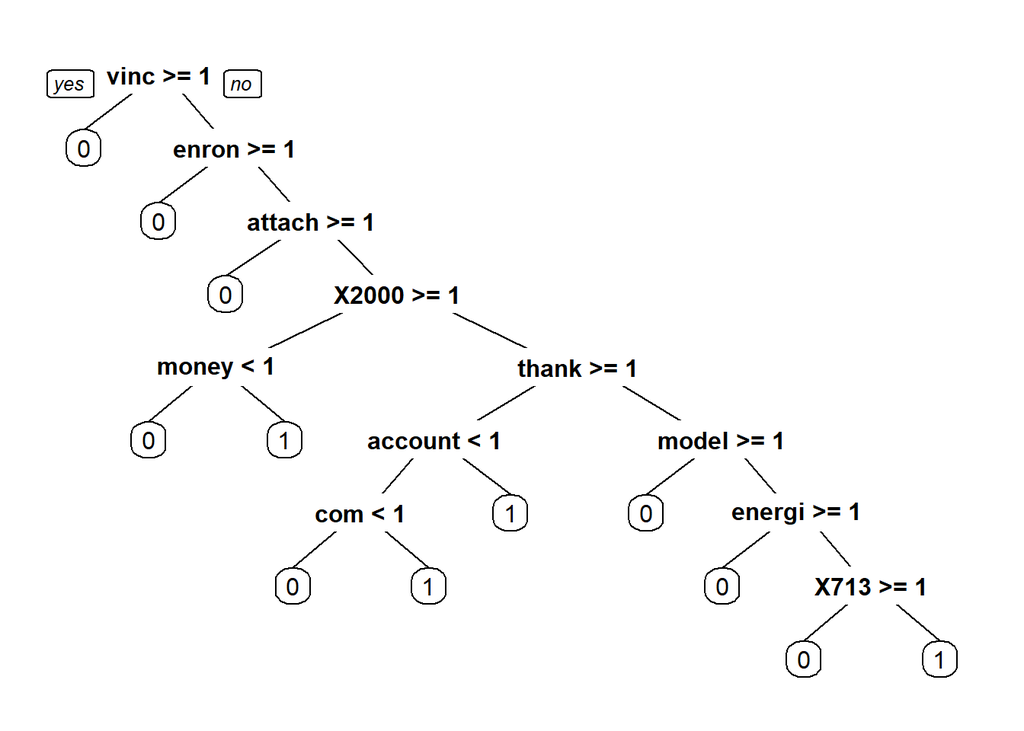

```r
prp(spamCART)
```

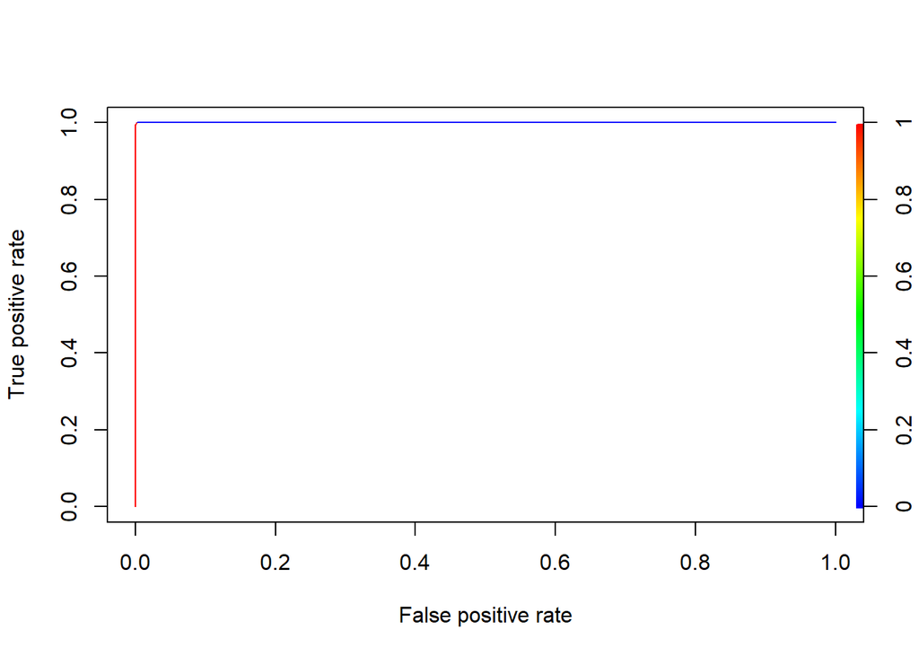

```r
predROCR <- prediction(predLog, train$spam)
perfROCR <- performance(predROCR, "tpr", "fpr")
plot(perfROCR, colorize = TRUE)
```

```r
performance(predROCR, "auc")@y.values
```

```
## [[1]]
## [1] 0.9999959
```

```r
as.numeric(performance(predROCR, "auc")@y.values)
```

```
## [1] 0.9999959
```

# Moving to CART model

What is the training set accuracy of spamCART, using a threshold of 0.5 for predictions? (Remember that if you used the type=“class” argument when making predictions, you automatically used a threshold of 0.5. If you did not add in the type argument to the predict function, the probabilities are in the second column of the predict output.)

```r
predCARTmail <- predict(spamCART, newdata = train, type = "class")
table(train$spam, predCARTmail)
```

```
##    predCARTmail
##        0    1
##   0 2885  167
##   1   64  894
```

```r
(2885+894)/nrow(train)
```

```
## [1] 0.942394
```

```r
predCARTmail2 <- predict(spamCART, newdata = train)
pred.prob2 <- predCARTmail2[,2]

predCartAUC <- prediction(pred.prob2, train$spam)
as.numeric(performance(predCartAUC, "auc")@y.values)
```

```
## [1] 0.9696044
```

# Random forest models

What is the training set accuracy of spamRF, using a threshold of 0.5 for predictions? (Remember that your answer might not match ours exactly, due to random behavior in the random forest algorithm on different operating systems.)

```r
predRFmail <- predict(spamRF, newdata = train)
table(train$spam, predRFmail)
```

```
##    predRFmail
##        0    1
##   0 3046    6
##   1    0  958
```

```r
(3046+968)/nrow(train)
```

```
## [1] 1.000998
```

```r
predRFmail.prob <- predict(spamRF, newdata = train, type = "prob")
probRF <- predRFmail.prob[,2]

predRFAUC <- prediction(probRF, train$spam)
as.numeric(performance(predRFAUC, "auc")@y.values)
```

[output not shown]

# Evaluating on test set

Obtain predicted probabilities for the testing set for each of the models, again ensuring that probabilities instead of classes are obtained.

What is the testing set accuracy of spamLog, using a threshold of 0.5 for predictions?

```r
predLogTest <- predict(spamLog, newdata = test, type = "response")
table(test$spam, predLogTest>0.5)
```

```
##
##     FALSE TRUE
##   0  1257   51
##   1    34  376
```

```r
(1257+376)/nrow(test)
```

```
## [1] 0.9505239
```

```r
predROCRlogTest <- prediction(predLogTest, test$spam)
as.numeric(performance(predROCRlogTest, "auc")@y.values)
```

```
## [1] 0.9627517
```

```r
# now spamCART TEST

predCARTmailtest <- predict(spamCART, newdata = test, type = "class")
table(test$spam, predCARTmailtest)
```

```
##    predCARTmailtest
##        0    1
##   0 1228   80
##   1   24  386
```

```r
(1228+386)/nrow(test)
```

```
## [1] 0.9394645
```

```r
predCARTmail2test <- predict(spamCART, newdata = test)
pred.prob2test <- predCARTmail2test[,2]

predCartAUC2test <- prediction(pred.prob2test, test$spam)
as.numeric(performance(predCartAUC2test, "auc")@y.values)
```

```
## [1] 0.963176
```

```r
# now spam RF TEST

predRFmailtest <- predict(spamRF, newdata = test)
table(test$spam, predRFmailtest)
```

```
##    predRFmailtest
##        0    1
##   0 1291   17
##   1   25  385
```

```r
(1291+385)/nrow(test)
```

```
## [1] 0.975553
```

```r
predRFmail.probtest <- predict(spamRF, newdata = test, type = "prob")
probRFtest <- predRFmail.probtest[,2]

predRFAUC_test <- prediction(probRFtest, test$spam)
as.numeric(performance(predRFAUC_test, "auc")@y.values)
```

```
## [1] 0.997768
```